# A Deep Dive into the S&P 500: Predicting Stock Prices

Kanishk Chinnapapannagari, Aarav Naveen, Avyay Potarlanka, and Melvin Rajendran

## Introduction

In today’s evolving financial landscape, both investors and traders are constantly seeking an edge to make informed decisions. The stock market, which contains an intricate web of variables and is influenced by numerous factors, has proven to be a difficult environment to navigate.

In the past, investment-related decisions were often made based on analysis of historical trends. However, the advancement of data science and machine learning techniques has introduced a new opportunity to potentially predict future stock prices with reasonable accuracy and thus gain valuable insights.

This data science project delves into prediction of stock prices within the Standard & Poor’s 500 index, otherwise known as the S&P 500. This index contains 500 of the top companies in the United States, and it represents approximately 80% of the U.S. stock market’s total value. Hence, it serves as a strong indicator of the movement within the market. To learn more about the S&P 500 and other popular indices in the U.S., read this article: https://www.investopedia.com/insights/introduction-to-stock-market-indices/.

Throughout this project, we will follow a comprehensive data science approach that includes the following steps:

- Data collection
- Data processing
- Exploratory data analysis and data visualization
- Data analysis, hypothesis testing, and machine learning (ML)
- Insight formation

```python
# Import necessary libraries
from bs4 import BeautifulSoup
from keras.layers import Dense, LSTM
from keras.models import Sequential
import matplotlib.pyplot as plt
import numpy as np
import os
import pandas as pd
import requests
import seaborn as sns
from sklearn.linear_model import LinearRegression
from sklearn.preprocessing import MinMaxScaler
from sklearn.preprocessing import LabelEncoder
```

[output not shown]

## Data Collection

### Reading in a Kaggle Dataset

To gather information about the S&P 500 companies, we will be using the following dataset: https://www.kaggle.com/datasets/paultimothymooney/stock-market-data. This Kaggle dataset contains the date, volume, and prices for the NASDAQ, NYSE, and S&P 500. For the purposes of this project, we will only analyze the stock prices of companies in the S&P 500.

```python
# Initialize an empty data frame to store the stock price data
price_data = pd.DataFrame()

# Initialize the path to the folder containing the data
folder_path = 'sp500-data'

# Iterate across each file in the folder by name
for file_name in os.listdir(folder_path):

    # Check if the current file is a CSV file
    if file_name.endswith('.csv'):

        # Read the current file into a temporary data frame
        temp = pd.read_csv(os.path.join(folder_path, file_name))

        # Extract the symbol from the current file's name
        symbol = file_name[0:-4]

        # Store the symbol in a new column in the temporary data frame
        temp['Symbol'] = symbol

        # Concatenate the accumulating and temporary data frames
        price_data = pd.concat([price_data, temp], ignore_index = True)

# Print the last five rows of the price data frame
price_data.tail()
```

|  | Date | Low | Open | Volume | High | Close | Adjusted Close | Symbol |
| --- | --- | --- | --- | --- | --- | --- | --- | --- |
| 3265995 | 06-12-2022 | 152.089996 | 154.220001 | 1964800.0 | 155.500000 | 153.050003 | 153.050003 | ZTS |
| 3265996 | 07-12-2022 | 149.380005 | 152.960007 | 2444100.0 | 153.789993 | 150.250000 | 150.250000 | ZTS |
| 3265997 | 08-12-2022 | 149.199997 | 150.529999 | 2267500.0 | 154.350006 | 153.679993 | 153.679993 | ZTS |
| 3265998 | 09-12-2022 | 152.740005 | 153.940002 | 3274900.0 | 156.330002 | 153.389999 | 153.389999 | ZTS |
| 3265999 | 12-12-2022 | 152.970001 | 154.070007 | 301135.0 | 154.470001 | 153.625000 | 153.625000 | ZTS |

### Webscraping From Wikipedia

We noticed that the Kaggle dataset does not contain sector data. For this reason, we will supplement our existing data with that which is contained on the following webpage: https://en.wikipedia.org/wiki/List_of_S%26P_500_companies. By scraping this webpage's list of the S&P 500 companies, we can match each company in our existing data to its corresponding GICS sector and sub-industry. This will enable us to perform analysis by sector and/or sub-industry and thus eliminate biases in our modeling.

```python
# Headers for the HTTP request
headers = {
    'User-Agent': 'Mozilla/5.0 (Macintosh; Intel Mac OS X 10_15_7) AppleWebKit/537.36 (KHTML, like Gecko) Chrome/109.0.0.0 Safari/537.36',
    'From': 'pleaseletmein@gmail.com'
}

# Make an HTTP request to the Wikipedia URL and store the response
response = requests.get('https://en.wikipedia.org/wiki/List_of_S%26P_500_companies', headers = headers)

# Parse the text from the webpage as HTML
soup = BeautifulSoup(response.text, 'html.parser')

# Find the table element containing the data and both extract and store the data
table = soup.find('table')

# Read the HTML table into a data frame
sector_data = pd.read_html(str(table), flavor = 'html5lib')[0]

# Print the last five rows of the sector data frame
sector_data.tail()
```

|  | Symbol | Security | GICS Sector | GICS Sub-Industry | Headquarters Location | Date added | CIK | Founded |
| --- | --- | --- | --- | --- | --- | --- | --- | --- |
| 498 | YUM | Yum! Brands | Consumer Discretionary | Restaurants | Louisville, Kentucky | 1997-10-06 | 1041061 | 1997 |
| 499 | ZBRA | Zebra Technologies | Information Technology | Electronic Equipment & Instruments | Lincolnshire, Illinois | 2019-12-23 | 877212 | 1969 |
| 500 | ZBH | Zimmer Biomet | Health Care | Health Care Equipment | Warsaw, Indiana | 2001-08-07 | 1136869 | 1927 |
| 501 | ZION | Zions Bancorporation | Financials | Regional Banks | Salt Lake City, Utah | 2001-06-22 | 109380 | 1873 |
| 502 | ZTS | Zoetis | Health Care | Pharmaceuticals | Parsippany, New Jersey | 2013-06-21 | 1555280 | 1952 |

### Webscraping From Slickcharts

We would also like to focus our attention on the top companies of each sector, as these companies drive the movement within their respective sectors. Hence, we will scrape the data from the following webpage: https://www.slickcharts.com/sp500. This webpage contains a list of the S&P 500 companies by weight, where weight is equal to a company's market cap divided by the overall value of the S&P 500. Ultimately, we will select the top companies of each sector by weight.

```python
# Make an HTTP request to the Slickcharts URL and store the response
response = requests.get('https://www.slickcharts.com/sp500', headers = headers)

# Parse the text from the webpage as HTML
soup = BeautifulSoup(response.text, 'html.parser')

# Find the table element containing the data and both extract and store the data
table = soup.find('table')

# Read the HTML table into a data frame
weight_data = pd.read_html(str(table), flavor = 'html5lib')[0]

# Print the last five rows of the sector data frame
weight_data.tail()
```

|  | # | Company | Symbol | Weight | Price | Chg | % Chg |
| --- | --- | --- | --- | --- | --- | --- | --- |
| 498 | 499 | Newell Brands Inc | NWL | 0.010325 | 9.27 | -0.23 | (-2.46%) |
| 499 | 500 | Zions Bancorporation N.A. | ZION | 0.009851 | 22.47 | -0.21 | (-0.93%) |
| 500 | 501 | Lincoln National Corp | LNC | 0.008901 | 19.26 | -0.68 | (-3.42%) |
| 501 | 502 | News Corporation Class B | NWS | 0.005934 | 18.99 | 2.16 | (12.80%) |
| 502 | 503 | DISH Network Corporation Class A | DISH | 0.004431 | 6.15 | -0.08 | (-1.28%) |

## Data Processing

At this point, we have three data frames containing data that was collected in the previous step. We will merge this data into a single data frame. Then, we will filter our data to include only the top five companies within each sector. As part of this process, we need to clean our data. Data cleaning will involve casting our data to the proper types, removing entries with missing values, and removing unnecessary columns.

### Cleaning the Sector Data

```python
# Rename the sector and industry-related columns
sector_data = sector_data.rename(columns = {'GICS Sector': 'Sector', 'GICS Sub-Industry': 'Industry'})

# Drop unnecessary columns
sector_data = sector_data.drop(['Headquarters Location', 'Date added', 'CIK', 'Founded'], axis = 1)

# Print the last five rows of the data frame
sector_data.tail()
```

|  | Symbol | Security | Sector | Industry |
| --- | --- | --- | --- | --- |
| 498 | YUM | Yum! Brands | Consumer Discretionary | Restaurants |
| 499 | ZBRA | Zebra Technologies | Information Technology | Electronic Equipment & Instruments |
| 500 | ZBH | Zimmer Biomet | Health Care | Health Care Equipment |
| 501 | ZION | Zions Bancorporation | Financials | Regional Banks |
| 502 | ZTS | Zoetis | Health Care | Pharmaceuticals |

### Cleaning the Weight Data

```python
# Drop all columns except Symbol and Weight
weight_data = weight_data.drop(['#', 'Company', 'Price', 'Chg', '% Chg'], axis = 1)

# Print the last five rows of the data frame
weight_data.tail()
```

|  | Symbol | Weight |
| --- | --- | --- |
| 498 | NWL | 0.010325 |
| 499 | ZION | 0.009851 |
| 500 | LNC | 0.008901 |
| 501 | NWS | 0.005934 |
| 502 | DISH | 0.004431 |

### Merging the Three Data Frames

```python
# Perform an inner join (merge) on all three data frames to create a single data frame
data = pd.merge(pd.merge(price_data, sector_data, on = 'Symbol'), weight_data, on = 'Symbol')

# Reindex the columns of the data frame
data = data.reindex(columns = ['Symbol', 'Security', 'Sector', 'Industry', 'Weight', 'Date', 'Open', 'High', 'Low', 'Close', 'Adjusted Close', 'Volume'])

# Cast the Date column's type to datetime
data['Date'] = pd.to_datetime(data['Date'], dayfirst = True)

# Print the last five rows of the resulting data frame
data.tail()
```

|  | Symbol | Security | Sector | Industry | Weight | Date | Open | High | Low | Close | Adjusted Close | Volume |
| --- | --- | --- | --- | --- | --- | --- | --- | --- | --- | --- | --- | --- |
| 2890656 | ZTS | Zoetis | Health Care | Pharmaceuticals | 0.249449 | 2022-12-06 | 154.220001 | 155.500000 | 152.089996 | 153.050003 | 153.050003 | 1964800.0 |
| 2890657 | ZTS | Zoetis | Health Care | Pharmaceuticals | 0.249449 | 2022-12-07 | 152.960007 | 153.789993 | 149.380005 | 150.250000 | 150.250000 | 2444100.0 |
| 2890658 | ZTS | Zoetis | Health Care | Pharmaceuticals | 0.249449 | 2022-12-08 | 150.529999 | 154.350006 | 149.199997 | 153.679993 | 153.679993 | 2267500.0 |
| 2890659 | ZTS | Zoetis | Health Care | Pharmaceuticals | 0.249449 | 2022-12-09 | 153.940002 | 156.330002 | 152.740005 | 153.389999 | 153.389999 | 3274900.0 |
| 2890660 | ZTS | Zoetis | Health Care | Pharmaceuticals | 0.249449 | 2022-12-12 | 154.070007 | 154.470001 | 152.970001 | 153.625000 | 153.625000 | 301135.0 |

### Filtering the Top 5 Companies Within Each Sector

```python
# Initialize an empty data frame to contain the filtered data
top_data = pd.DataFrame()

# Iterate across a list of the unique sectors
for sector in data['Sector'].unique():

    # Filter the data by the current sector
    sector_data = data[data['Sector'] == sector]

    # Compile a list of the top five weights in the current sector
    top_five_weights = sorted(sector_data['Weight'].unique(), reverse = True)[:5]

    # Filter the data by the top five weights
    sector_data = sector_data[sector_data['Weight'].isin(top_five_weights)]

    # Concatenate the top five companies' data into the accumulating dataframe
    top_data = pd.concat([top_data, sector_data], ignore_index = True)

# Print the last five rows of the filtered data frame
top_data.tail()
```

|  | Symbol | Security | Sector | Industry | Weight | Date | Open | High | Low | Close | Adjusted Close | Volume |
| --- | --- | --- | --- | --- | --- | --- | --- | --- | --- | --- | --- | --- |
| 518500 | VZ | Verizon | Communication Services | Integrated Telecommunication Services | 0.457305 | 2022-12-06 | 36.990002 | 37.070000 | 36.630001 | 36.889999 | 36.889999 | 26293700.0 |
| 518501 | VZ | Verizon | Communication Services | Integrated Telecommunication Services | 0.457305 | 2022-12-07 | 36.740002 | 37.310001 | 36.669998 | 37.169998 | 37.169998 | 23065900.0 |
| 518502 | VZ | Verizon | Communication Services | Integrated Telecommunication Services | 0.457305 | 2022-12-08 | 37.110001 | 37.240002 | 36.869999 | 37.099998 | 37.099998 | 19549100.0 |
| 518503 | VZ | Verizon | Communication Services | Integrated Telecommunication Services | 0.457305 | 2022-12-09 | 37.209999 | 37.630001 | 36.959999 | 37.400002 | 37.400002 | 20669100.0 |
| 518504 | VZ | Verizon | Communication Services | Integrated Telecommunication Services | 0.457305 | 2022-12-12 | 37.689999 | 37.730000 | 37.279999 | 37.615002 | 37.615002 | 4698435.0 |

## Exploratory Data Analysis and Data Visualization

Before we fit a machine learning model to our data, we would like to visualize it by sector and preliminarily determine relationships between the data. In particular, we would like to analyze how strongly the stock prices of companies within the same sector are correlated.

For the remainder of our analysis, we will focus our attention on adjusted close price, which is explained in the following section.

### Plotting Adjusted Close Price vs. Date

Adjusted close price is the final price at which a security trades at the end of a trading day, adjusting for dividends, stock splits, and new offerings. It is the most accurate representation of a company's stock price, and it is commonly used by investors and traders to track performance.

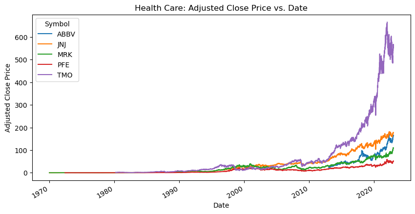

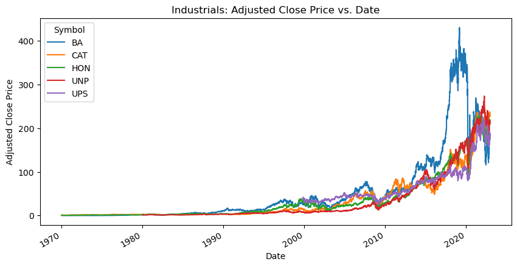

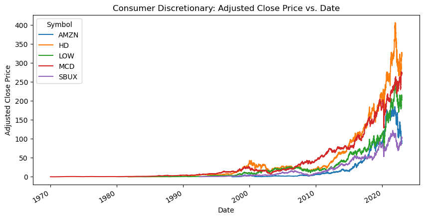

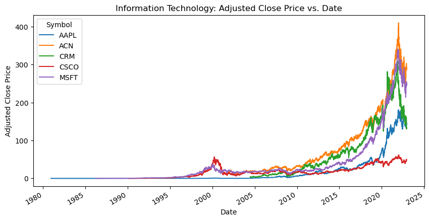

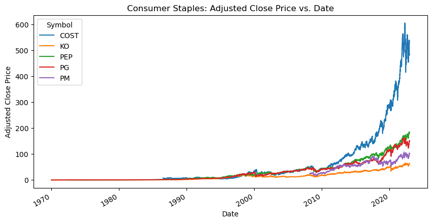

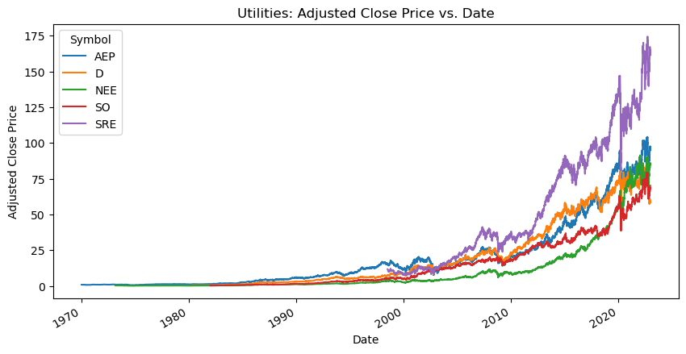

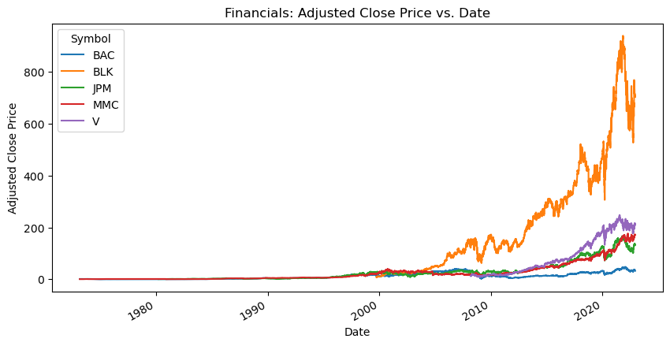

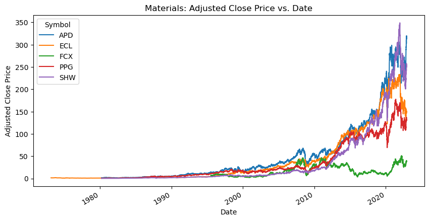

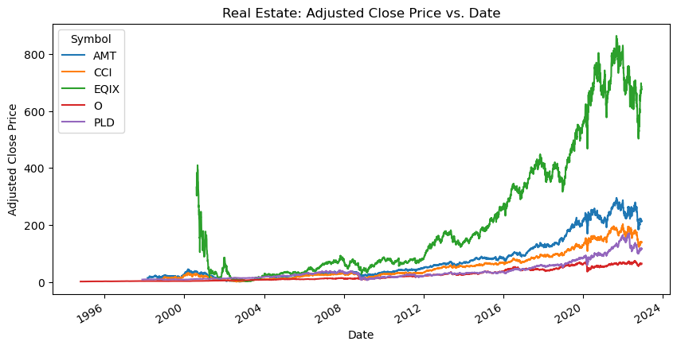

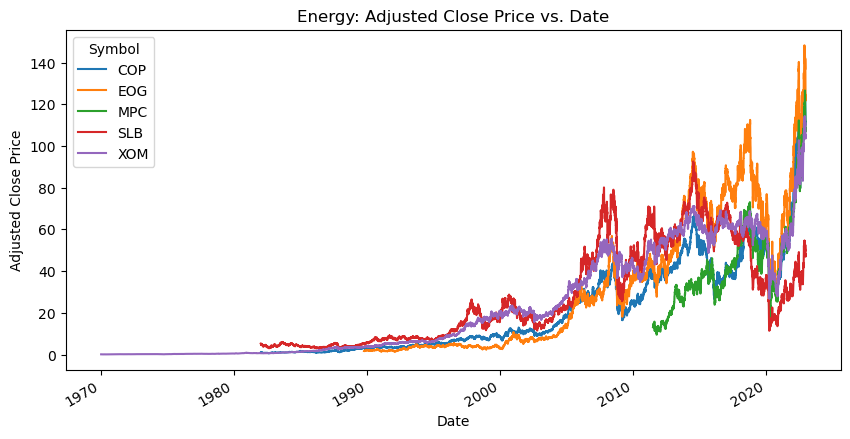

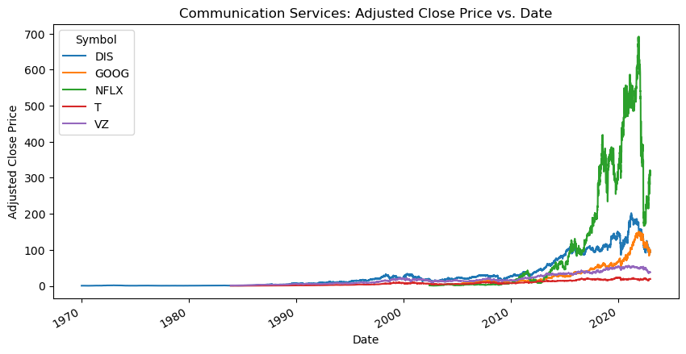

```python
# Generate a plot for the top five companies in each sector
for sector in top_data['Sector'].unique():

    # Filter the data for the current sector
    sector_data = top_data[top_data['Sector'] == sector]

    # Reshape the data for plotting purposes
    sec_as_row = sector_data.pivot(index = 'Date', columns = 'Symbol', values = 'Adjusted Close')

    # Generate plot
    sec_as_row.plot(title = f'{sector}: Adjusted Close Price vs. Date', legend = True, xlabel = 'Date', ylabel = 'Adjusted Close Price', figsize = (10, 5))
```

Above are 11 line plots of adjusted close price vs. date for the the top five companies (by weight) in each sector.

### Plotting Volume vs. Date

Volume traded is the number of shares that are transferred between constituents during the trading day. This is an important metric for investors and traders to consider.

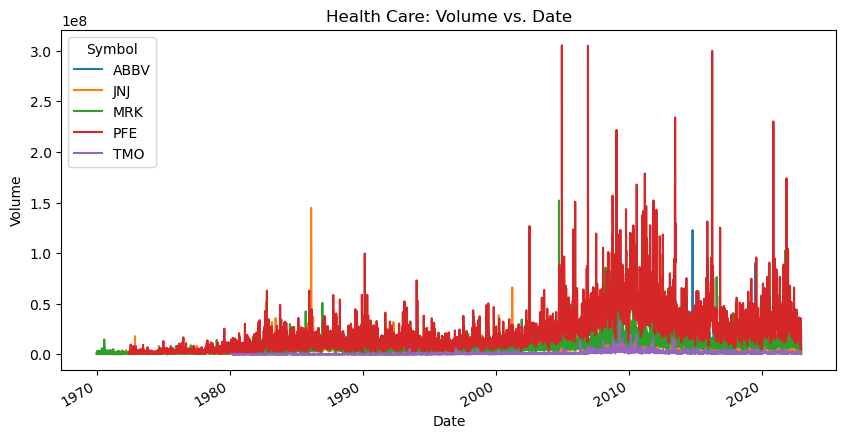

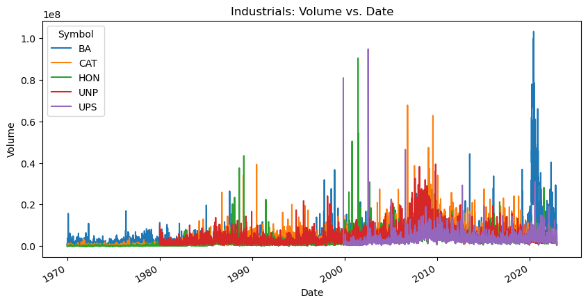

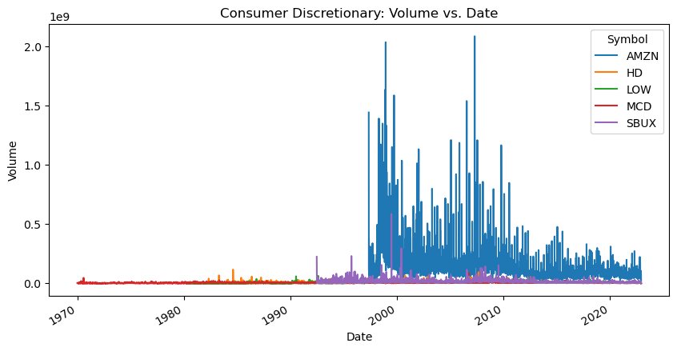

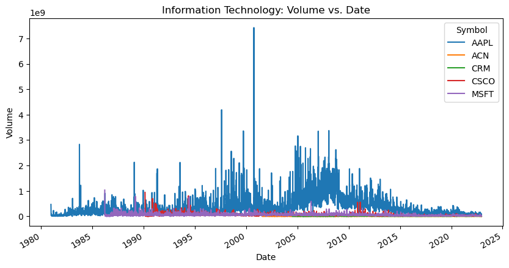

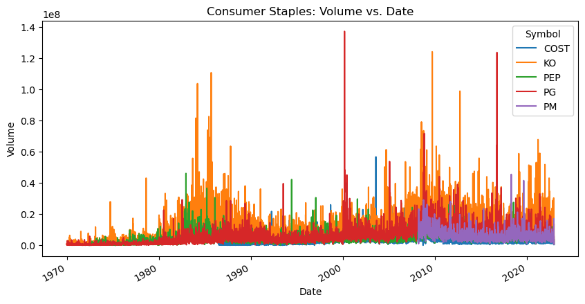

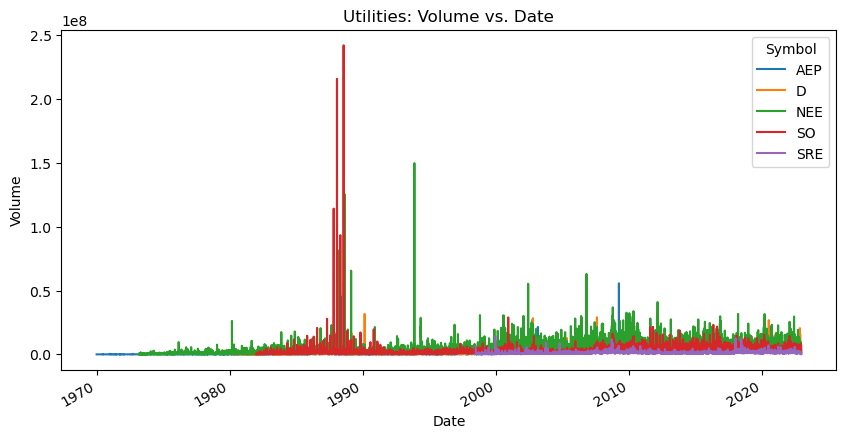

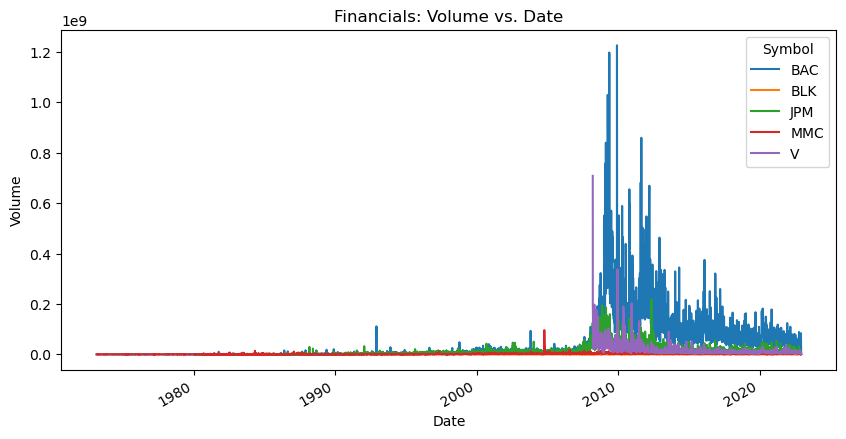

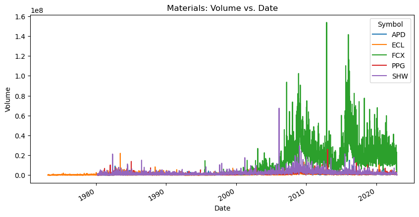

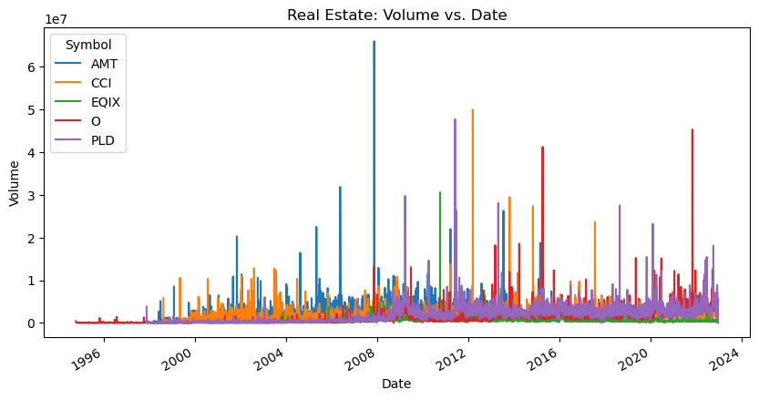

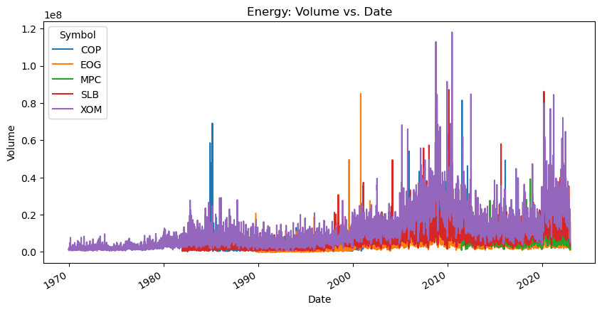

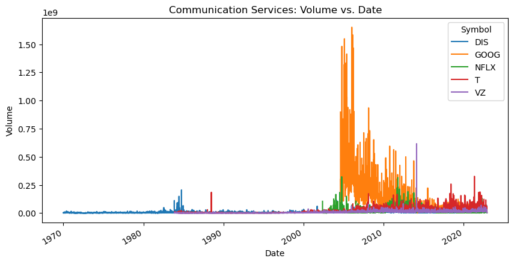

```python
# Generate a plot for the top five companies in each sector
for sector in top_data['Sector'].unique():

    # Filter the data for the current sector
    sector_data = top_data[top_data['Sector'] == sector]

    # Reshape the data for plotting purposes
    sec_as_row = sector_data.pivot(index = 'Date', columns = 'Symbol', values = 'Volume')

    # Generate plot
    sec_as_row.plot(title = f'{sector}: Volume vs. Date', legend = True, xlabel = 'Date', ylabel = 'Volume', figsize = (10, 5))
```

Above are 11 line plots of volume traded vs. date for the the top five companies (by weight) in each sector.

### Calculating Various Moving Averages

Moving average standardizes the price of a stock by converting it to a constantly updated average price. This average is calculated over a predetermined time period. The most relevant and commonly used time periods for calculating moving average are 10 days and 20 days.

```python
# Lengths of moving averages (in days) to calculate
moving_averages = [10, 20]

# Iterate across the moving averages
for ma in moving_averages:

    # Iterate across each company
    for security in top_data['Security'].unique():

        # Filter the data for the current company
        security_data = top_data[top_data['Security'] == security]

        # Add a column containing the current company's moving average
        top_data[f'{ma}-Day Moving Average'] = top_data['Adjusted Close'].rolling(ma).mean()

# Print the last five rows of the data frame
top_data.tail()
```

|  | Symbol | Security | Sector | Industry | Weight | Date | Open | High | Low | Close | Adjusted Close | Volume | 10-Day Moving Average | 20-Day Moving Average |
| --- | --- | --- | --- | --- | --- | --- | --- | --- | --- | --- | --- | --- | --- | --- |
| 518500 | VZ | Verizon | Communication Services | Integrated Telecommunication Services | 0.457305 | 2022-12-06 | 36.990002 | 37.070000 | 36.630001 | 36.889999 | 36.889999 | 26293700.0 | 38.3170 | 38.23500 |
| 518501 | VZ | Verizon | Communication Services | Integrated Telecommunication Services | 0.457305 | 2022-12-07 | 36.740002 | 37.310001 | 36.669998 | 37.169998 | 37.169998 | 23065900.0 | 38.1140 | 38.20000 |
| 518502 | VZ | Verizon | Communication Services | Integrated Telecommunication Services | 0.457305 | 2022-12-08 | 37.110001 | 37.240002 | 36.869999 | 37.099998 | 37.099998 | 19549100.0 | 37.9320 | 38.17400 |
| 518503 | VZ | Verizon | Communication Services | Integrated Telecommunication Services | 0.457305 | 2022-12-09 | 37.209999 | 37.630001 | 36.959999 | 37.400002 | 37.400002 | 20669100.0 | 37.7700 | 38.11800 |
| 518504 | VZ | Verizon | Communication Services | Integrated Telecommunication Services | 0.457305 | 2022-12-12 | 37.689999 | 37.730000 | 37.279999 | 37.615002 | 37.615002 | 4698435.0 | 37.7075 | 38.08375 |

### Calculating Daily Returns

Daily return is the percentage change in the price of stock over the course of a trading day. This will help us assess the risk of investing in a particular company.

```python
# Initialize an empty data frame to contain the daily return values
return_data = pd.DataFrame()

# Iterate across the sectors
for security in top_data['Security'].unique():

    # Filter the data for the current security
    security_data = top_data[top_data['Security'] == security]

    # Calculate the percent change i.e. daily return
    security_rets = pd.DataFrame(security_data['Adjusted Close'].pct_change())

    # Append this data to the accumulating data frame
    return_data = pd.concat([return_data, security_rets], ignore_index = True)

# Add the daily return values to the top company data frame
top_data['Daily Return'] = return_data

# Print the last five rows of the top data frame
top_data.tail()
```

|  | Symbol | Security | Sector | Industry | Weight | Date | Open | High | Low | Close | Adjusted Close | Volume | 10-Day Moving Average | 20-Day Moving Average | Daily Return |
| --- | --- | --- | --- | --- | --- | --- | --- | --- | --- | --- | --- | --- | --- | --- | --- |
| 518500 | VZ | Verizon | Communication Services | Integrated Telecommunication Services | 0.457305 | 2022-12-06 | 36.990002 | 37.070000 | 36.630001 | 36.889999 | 36.889999 | 26293700.0 | 38.3170 | 38.23500 | -0.004856 |
| 518501 | VZ | Verizon | Communication Services | Integrated Telecommunication Services | 0.457305 | 2022-12-07 | 36.740002 | 37.310001 | 36.669998 | 37.169998 | 37.169998 | 23065900.0 | 38.1140 | 38.20000 | 0.007590 |
| 518502 | VZ | Verizon | Communication Services | Integrated Telecommunication Services | 0.457305 | 2022-12-08 | 37.110001 | 37.240002 | 36.869999 | 37.099998 | 37.099998 | 19549100.0 | 37.9320 | 38.17400 | -0.001883 |
| 518503 | VZ | Verizon | Communication Services | Integrated Telecommunication Services | 0.457305 | 2022-12-09 | 37.209999 | 37.630001 | 36.959999 | 37.400002 | 37.400002 | 20669100.0 | 37.7700 | 38.11800 | 0.008086 |
| 518504 | VZ | Verizon | Communication Services | Integrated Telecommunication Services | 0.457305 | 2022-12-12 | 37.689999 | 37.730000 | 37.279999 | 37.615002 | 37.615002 | 4698435.0 | 37.7075 | 38.08375 | 0.005749 |

### Plotting and Comparing the Daily Returns of Various Stocks

Next, we will plot the daily returns of various stocks against one another. This will help us assess whether the stock prices of companies in the same sector are strongly correlated or not. We expect that they are linearly and positively correlated.

For the purposes of this project, we will only show the plot for the Information Technology sector. This will avoid long, repetitive outputs.

```python
# Initialize a data frame to contain the formatted data for plotting
formatted_data = top_data[['Symbol', 'Date', 'Daily Return']]

# Pivots the ticker symbols from a column's entries to column headers
formatted_data = formatted_data.pivot(index = 'Date', columns = 'Symbol', values = 'Daily Return')

# Print the last five rows of the formatted data frame
formatted_data.tail()
```

| Symbol Date | AAPL | ABBV | ACN | AEP | AMT | AMZN | APD | BA | BAC | BLK | ... | SLB | SO | SRE | T | TMO | UNP | UPS | V | VZ | XOM |
| --- | --- | --- | --- | --- | --- | --- | --- | --- | --- | --- | --- | --- | --- | --- | --- | --- | --- | --- | --- | --- | --- |
| 2022-12-06 | -0.025370 | -0.001342 | -0.025039 | 0.019573 | -0.014331 | -0.030326 | -0.009112 | -0.036035 | -0.042646 | 0.003404 | ... | -0.006347 | 0.014819 | 0.010141 | 0.022400 | -0.011988 | 0.000379 | -0.033451 | -0.021527 | -0.004856 | -0.027796 |
| 2022-12-07 | -0.013785 | 0.010261 | 0.004485 | 0.003113 | -0.006635 | 0.002380 | 0.011150 | -0.010817 | -0.007879 | -0.001591 | ... | -0.021226 | 0.000292 | -0.017720 | 0.006781 | 0.013823 | 0.005115 | -0.002456 | -0.006074 | 0.007590 | -0.002214 |
| 2022-12-08 | 0.012133 | 0.003567 | 0.019045 | 0.010862 | 0.005400 | 0.021366 | 0.013562 | 0.014618 | -0.009163 | -0.008066 | ... | 0.002410 | 0.002628 | -0.001970 | -0.009326 | 0.017576 | 0.003817 | 0.028396 | 0.006208 | -0.001883 | 0.007429 |
| 2022-12-09 | -0.003435 | -0.017652 | -0.012802 | -0.011666 | 0.007491 | -0.013946 | -0.017039 | 0.002569 | -0.001849 | 0.004990 | ... | -0.059094 | -0.004659 | -0.005861 | -0.001569 | -0.013593 | -0.007886 | -0.011078 | -0.001913 | 0.008086 | -0.008427 |
| 2022-12-12 | 0.000563 | 0.002112 | 0.010090 | 0.004608 | 0.001356 | -0.006566 | 0.003037 | 0.038265 | 0.005405 | -0.003105 | ... | 0.023206 | 0.025819 | 0.009246 | 0.005500 | 0.010951 | 0.004353 | 0.019815 | 0.022377 | 0.005749 | 0.017288 |

5 rows × 55 columns

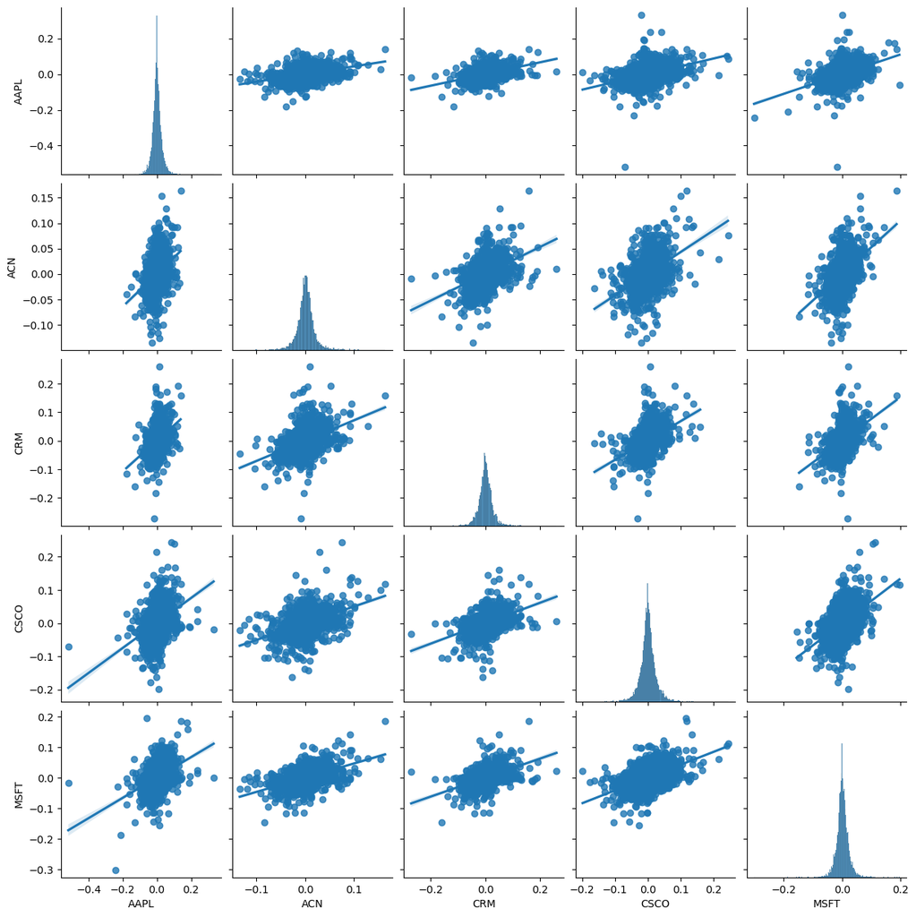

```python
# Pair plot the comparisons of daily returns for all companies in the Information Technology sector
sns.pairplot(formatted_data[['AAPL', 'ACN', 'CRM', 'CSCO', 'MSFT']], kind = 'reg')
```

The above plot is a pair plot for the daily returns of the top five companies (by weight) in the Information Technology sector. It is apparent that there is a somewhat linear correlation between the companies, with some outlying cases. In general, as one company's daily return increases, the daily returns of the other companies increase. Hence, we can proceed with our modeling.

## Data Analysis, Hypothesis Testing, and Machine Learning

We will be implementing the Sequential machine learning model from the Keras library. This works by having several different types of layers that sequentially feed into eachother during the training process. Each layer performs a unique computation on the input data and the model feeds the output of that layer to another layer.

Source: https://www.educba.com/keras-sequential/

### Filtering the Data to Google

At this point in our analysis, we will focus our attention on a company that is driving a lot of movement within the S&P 500: Google. Google is an industry leader in the Communication Services sector and its respective industry. This decision was made by our team because of computational limitations with regard to training the following machine learning model. This process is both time-consuming and resource-intensive. Note that this modeling could be applied to any company in the S&P 500.

```python
# Filter the data to only contain the symbol and adjusted close
goog_data = top_data.filter(['Date', 'Adjusted Close', 'Symbol'])

# Filter the data to only contain the data for Google
goog_data = goog_data[goog_data['Symbol'] == 'GOOG']

# Drop the symbol column
goog_data = goog_data.drop(columns = ['Symbol'])

# Set date to the data frame's index
goog_data.set_index('Date', inplace = True)

# Print the last five rows of the data frame
goog_data.head()
```

| Date | Adjusted Close |
| --- | --- |
| 2004-08-19 | 2.499133 |
| 2004-08-20 | 2.697639 |
| 2004-08-23 | 2.724787 |
| 2004-08-24 | 2.611960 |
| 2004-08-25 | 2.640104 |

### Long Short-Term Memory Modeling

Our goal is to predict the future stock prices of Google (ticker GOOG). In order to do so, we need to train and fit a model that could then estimate stock prices in the immediate future. We can use an LTSM model, or a Long Short-Term Memory model, designed by Fares Sayah at Kaggle, and modify it so our data could be used instead.

In this case, our goal is to predict the future stock prices of Google.

Thanks to Fares Sayah for his documentation of this particular model! To read more: https://www.kaggle.com/code/faressayah/stock-market-analysis-prediction-using-lstm/notebook.

#### Organizing the Training Data

Ideally, we can use 95% of our data to train our model.

```python
# Select the values to be trained
pre_train = goog_data.values

# Calculate the length of the training data
training_data_len = int(np.ceil(len(pre_train) * .95))

# Print this length
training_data_len
```

```
4382
```

#### Fitting the Data and Getting the Training Data

We need the data from the range of (0,1) to make sure that all of the values are in a similar range to make our machine learning model more accurate. We can then prepare the training data to be used by our model

```python
# Create a scaler
scaler = MinMaxScaler(feature_range = (0, 1))

# Create scaled data
scaled_data = scaler.fit_transform(pre_train)

# Print the scaled data frame
scaled_data
```

```
array([[5.54601395e-05],
       [1.39474256e-03],
       [1.57790515e-03],
       ...,
       [6.17057513e-01],
       [6.11120335e-01],
       [6.07105972e-01]])
```

#### Building and Training the Model

The machine learning model used here is the Sequential model from the Keras library. This model is useful when there is one precisely input and one output. This holds in our case since the model process stock prices over time in order to make a singular prediction for a singular point in time.

```python
# Total training data
train_data = scaled_data[0:int(training_data_len), :]

x_train = []
y_train = []

# Split training data for x and y axis
for i in range(60, len(train_data)):
    x_train.append(train_data[i-60:i, 0])
    y_train.append(train_data[i, 0])
    if i<= 61:
        print(x_train)
        print(y_train)
        print()

# Convert the x_train and y_train to numpy arrays
x_train, y_train = np.array(x_train), np.array(y_train)

# Reshape the data
x_train = np.reshape(x_train, (x_train.shape[0], x_train.shape[1], 1))

# Build the LSTM model
model = Sequential()
model.add(LSTM(128, return_sequences=True, input_shape= (x_train.shape[1], 1)))
model.add(LSTM(64, return_sequences=False))
model.add(Dense(25))
model.add(Dense(1))

# Compile the model
model.compile(optimizer='adam', loss='mean_squared_error')

# Train the model
model.fit(x_train, y_train, batch_size=1, epochs=1)
```

```
[array([5.54601395e-05, 1.39474256e-03, 1.57790515e-03, 8.16681841e-04,
       1.00656502e-03, 1.32752381e-03, 1.03177125e-03, 3.36085743e-04,
       3.96579086e-04, 4.03331846e-05, 2.52062297e-04, 0.00000000e+00,
       2.63827349e-04, 3.84818860e-04, 3.86498202e-04, 8.93979873e-04,
       1.25862571e-03, 1.92911142e-03, 2.01480938e-03, 2.34584744e-03,
       2.93735417e-03, 3.25158754e-03, 2.99616656e-03, 3.08690416e-03,
       3.49692925e-03, 3.33056652e-03, 3.06674561e-03, 4.51189259e-03,
       5.22102410e-03, 4.97232210e-03, 5.47308479e-03, 5.88982081e-03,
       6.44603560e-03, 6.22926685e-03, 6.52669393e-03, 6.33849170e-03,
       5.92343341e-03, 6.28303960e-03, 6.87117960e-03, 7.05602153e-03,
       7.41058809e-03, 8.25919514e-03, 8.05418662e-03, 6.80228150e-03,
       8.29616160e-03, 1.21695001e-02, 1.46850625e-02, 1.37440385e-02,
       1.44447685e-02, 1.56765022e-02, 1.52295171e-02, 1.61352524e-02,
       1.59403296e-02, 1.54025956e-02, 1.42313536e-02, 1.16519311e-02,
       1.21896587e-02, 1.15427095e-02, 1.14015514e-02, 1.39490471e-02])]
[0.013777644707187047]

[array([5.54601395e-05, 1.39474256e-03, 1.57790515e-03, 8.16681841e-04,
       1.00656502e-03, 1.32752381e-03, 1.03177125e-03, 3.36085743e-04,
       3.96579086e-04, 4.03331846e-05, 2.52062297e-04, 0.00000000e+00,
       2.63827349e-04, 3.84818860e-04, 3.86498202e-04, 8.93979873e-04,
       1.25862571e-03, 1.92911142e-03, 2.01480938e-03, 2.34584744e-03,
       2.93735417e-03, 3.25158754e-03, 2.99616656e-03, 3.08690416e-03,
       3.49692925e-03, 3.33056652e-03, 3.06674561e-03, 4.51189259e-03,
       5.22102410e-03, 4.97232210e-03, 5.47308479e-03, 5.88982081e-03,
       6.44603560e-03, 6.22926685e-03, 6.52669393e-03, 6.33849170e-03,
       5.92343341e-03, 6.28303960e-03, 6.87117960e-03, 7.05602153e-03,
       7.41058809e-03, 8.25919514e-03, 8.05418662e-03, 6.80228150e-03,
       8.29616160e-03, 1.21695001e-02, 1.46850625e-02, 1.37440385e-02,
       1.44447685e-02, 1.56765022e-02, 1.52295171e-02, 1.61352524e-02,
       1.59403296e-02, 1.54025956e-02, 1.42313536e-02, 1.16519311e-02,
       1.21896587e-02, 1.15427095e-02, 1.14015514e-02, 1.39490471e-02]), array([1.39474256e-03, 1.57790515e-03, 8.16681841e-04, 1.00656502e-03,
       1.32752381e-03, 1.03177125e-03, 3.36085743e-04, 3.96579086e-04,
       4.03331846e-05, 2.52062297e-04, 0.00000000e+00, 2.63827349e-04,
       3.84818860e-04, 3.86498202e-04, 8.93979873e-04, 1.25862571e-03,
       1.92911142e-03, 2.01480938e-03, 2.34584744e-03, 2.93735417e-03,
       3.25158754e-03, 2.99616656e-03, 3.08690416e-03, 3.49692925e-03,
       3.33056652e-03, 3.06674561e-03, 4.51189259e-03, 5.22102410e-03,
       4.97232210e-03, 5.47308479e-03, 5.88982081e-03, 6.44603560e-03,
       6.22926685e-03, 6.52669393e-03, 6.33849170e-03, 5.92343341e-03,
       6.28303960e-03, 6.87117960e-03, 7.05602153e-03, 7.41058809e-03,
       8.25919514e-03, 8.05418662e-03, 6.80228150e-03, 8.29616160e-03,
       1.21695001e-02, 1.46850625e-02, 1.37440385e-02, 1.44447685e-02,
       1.56765022e-02, 1.52295171e-02, 1.61352524e-02, 1.59403296e-02,
       1.54025956e-02, 1.42313536e-02, 1.16519311e-02, 1.21896587e-02,
       1.15427095e-02, 1.14015514e-02, 1.39490471e-02, 1.37776447e-02])]
[0.013777644707187047, 0.014259921756710325]
```

[output not shown]

[output cut: 12 more lines]

```
<keras.callbacks.History at 0x7f54f854d870>
```

```python
# Create a new array containing scaled values from index 1543 to 2002
test_data = scaled_data[training_data_len - 60: , :]
# Create the data sets x_test and y_test
x_test = []
y_test = pre_train[training_data_len:, :]
for i in range(60, len(test_data)):
    x_test.append(test_data[i-60:i, 0])

# Convert the data to a numpy array
x_test = np.array(x_test)

# Reshape the data
x_test = np.reshape(x_test, (x_test.shape[0], x_test.shape[1], 1 ))

# Get the models predicted price values
predictions = model.predict(x_test)
predictions = scaler.inverse_transform(predictions)

# Get the root mean squared error (RMSE)
rmse = np.sqrt(np.mean(((predictions - y_test) ** 2)))

rmse
```

[output not shown]

```
4.739062835437262
```

```python
# Calculate range of stock price in order to contextualize RMSE

min_price = min(goog_data['Adjusted Close'])
max_price = max(goog_data['Adjusted Close'])

print(f'The GOOG stock price ranges from {min_price} to {max_price}')
```

```
The GOOG stock price ranges from 2.490912914276123 to 150.70899963378906
```

Root Mean Squared Error is a statistic used to evaluate the accuracy of the model's predictions.

#### Plotting the Predicted GOOG Stock Prices

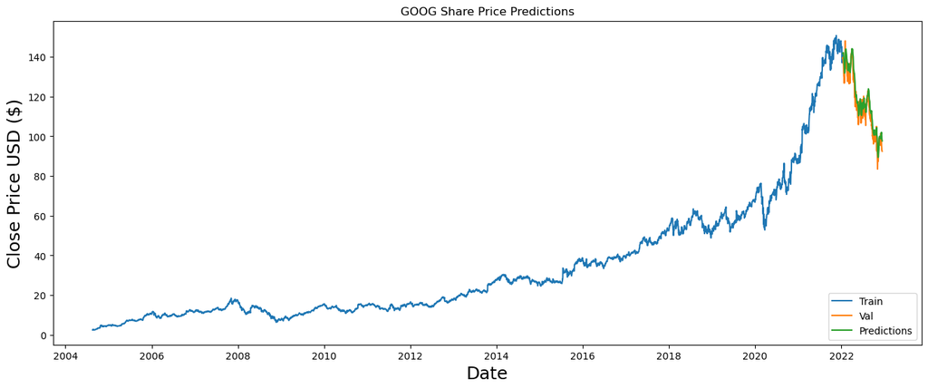

```python
# Plot the data
train = top_data[top_data['Symbol'] == 'GOOG'][:training_data_len]
valid = top_data[top_data['Symbol'] == 'GOOG'][training_data_len:]
valid['Predictions'] = predictions

# Visualize the data
plt.figure(figsize = (16,6))
plt.title('GOOG Share Price Predictions')
plt.xlabel('Date', fontsize = 18)
plt.ylabel('Close Price USD ($)', fontsize = 18)
plt.plot(train['Date'], train['Close'])
plt.plot(valid['Date'], valid[['Close', 'Predictions']])
plt.legend(['Train', 'Val', 'Predictions'], loc = 'lower right')
plt.show()
```

## Insights

In general this project involved a large amount of cleaning and processing data, urging us to learn how to omptimally categorize information in a way that makes trends/patterns in the data visually understandable instead of being overwhelmed by the sheer quantity of data provided. The collection process was also extensive as we learned that all the necessary data to carry out the operation is not always easily found in one source. Instead we had to combine several sources to make sure the necessary information was there. When it comes to the predictive algorithm we learned about selcting the right model and the extensive process required to modify data into the correct format required for that machine learning model. However, Applying the model, seeing the predictions, and understanding the accuracy of those predictions was truly exciting.

Our model has proven to be moderately accurate in predicting stock prices as shown by the showcase of the prediction on GOOG. However, given the high stakes nature of stock trading, predictions provided are held to a signficantly higher standard and so while out model is pretty good at predicting stock prices, it isn't something that can be applied to real world cases just yet.

The finance industry is the foundation of modern capitalism and as technology continues to rapidly develop, data science is used to make predicitions that optimize stock trades beyond the capabilites of humans allowing the industry to further develop and flourish. Therefore data science and the concepts discussed throughout this project have powerful real world applications, directly impacting the way our world runs today and develops in the future.